# FinalMelt

Rhomberg, Giacotto, Arias

11/6/2019

## 2016

```r
clean2016 %>%  group_by(flg_NetDep, Dropped) %>%
  count() %>% spread(Dropped, n)
```

```
## # A tibble: 2 x 3
## # Groups:   flg_NetDep [2]
##   flg_NetDep `FALSE` `TRUE`
##        <dbl>   <int>  <int>
## 1          0       1   1499
## 2          1     326     10
```

```r
# 326/336 is who stayed = 0.9702381
```

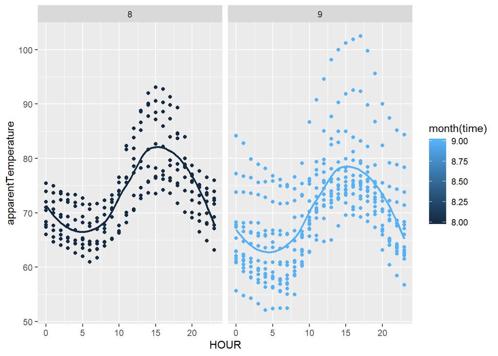

```r
cleanWeather2016 %>% gf_point(apparentTemperature ~ HOUR, color = ~ month(time)) %>% gf_smooth(apparentTemperature~HOUR, method = loess, colorse = TRUE) %>% gf_facet_wrap(~month(time))
```

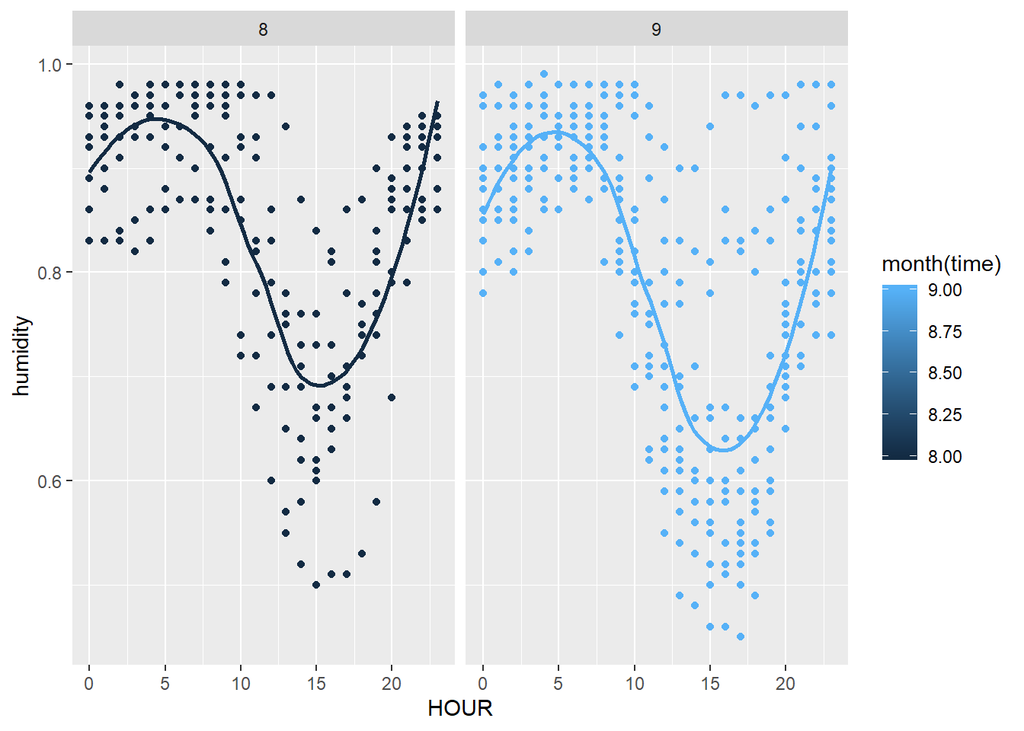

```r
cleanWeather2016 %>% gf_point(humidity ~ HOUR, color = ~ month(time)) %>% gf_smooth(humidity~HOUR, method = loess, colorse = TRUE) %>% gf_facet_wrap(~month(time))
```

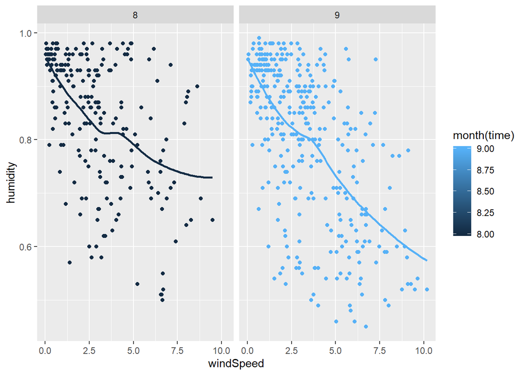

```r
cleanWeather2016 %>% gf_point(humidity ~ windSpeed, color = ~ month(time)) %>% gf_smooth(humidity~windSpeed, method = loess, colorse = TRUE) %>% gf_facet_wrap(~month(time))
```

```r
cleanWeather2016 %>% group_by(HOUR) %>% summarise(MeanTemp=mean(apparentTemperature))
```

```
## # A tibble: 24 x 2
##     HOUR MeanTemp
##    <int>    <dbl>
##  1     0     67.7
##  2     1     67.0
##  3     2     66.2
##  4     3     65.5
##  5     4     64.9
##  6     5     64.4
##  7     6     63.7
##  8     7     63.6
##  9     8     65.3
## 10     9     67.8
## # ... with 14 more rows
```

## 2017

```r
clean2017 %>%  group_by(flg_NetDep, Dropped) %>%
  count() %>% spread(Dropped, n)
```

```
## # A tibble: 2 x 3
## # Groups:   flg_NetDep [2]
##   flg_NetDep `FALSE` `TRUE`
##        <dbl>   <int>  <int>
## 1          0       4   1351
## 2          1     332      7
```

```r
# 332/339 is who stayed = 0.97935103
```

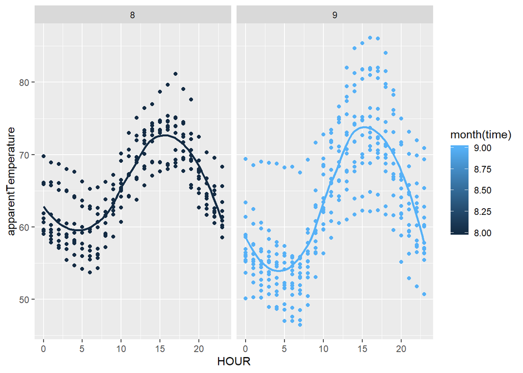

```r
cleanWeather2017 %>% gf_point(apparentTemperature ~ HOUR, color = ~ month(time)) %>% gf_smooth(apparentTemperature~HOUR, method = loess, colorse = TRUE) %>% gf_facet_wrap(~month(time))
```

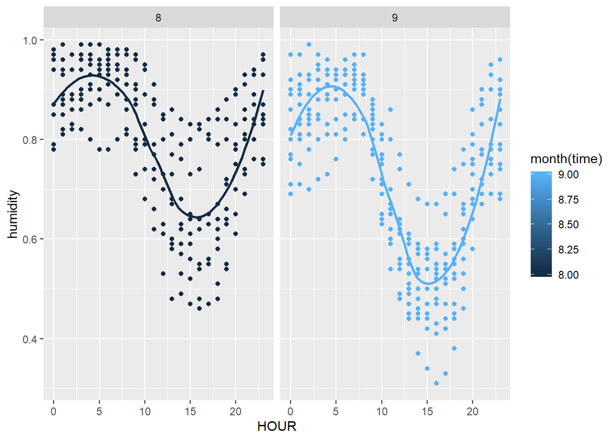

```r
cleanWeather2017 %>% gf_point(humidity ~ HOUR, color = ~ month(time)) %>% gf_smooth(humidity~HOUR, method = loess, colorse = TRUE) %>% gf_facet_wrap(~month(time))
```

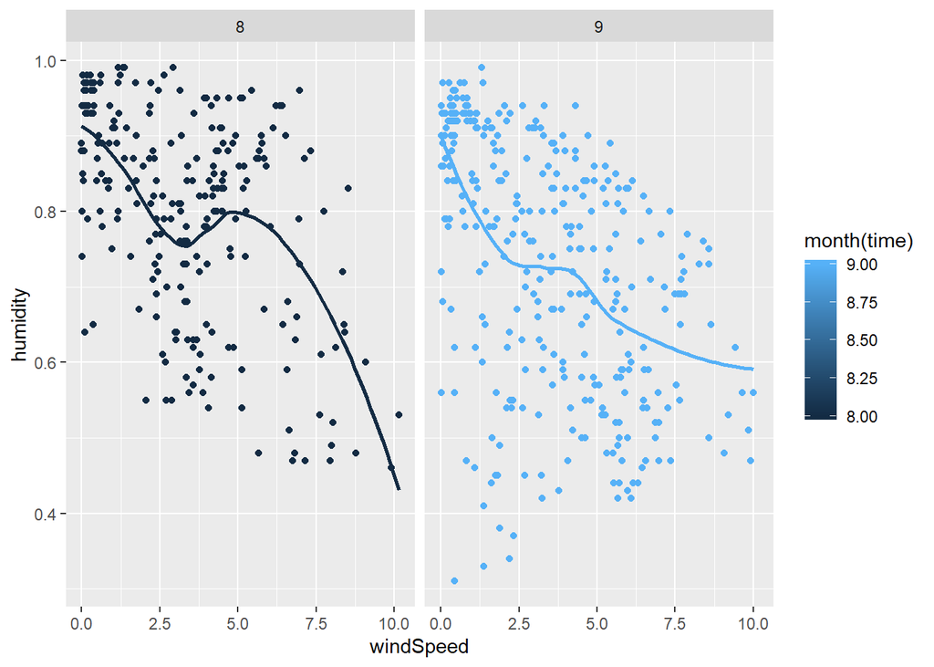

```r
cleanWeather2017 %>% gf_point(humidity ~ windSpeed, color = ~ month(time)) %>% gf_smooth(humidity~windSpeed, method = loess, colorse = TRUE) %>% gf_facet_wrap(~month(time))
```

2017 was the second year with the lowest percentage of people who dropped with only 7 of the 339 leaving for a 2.064897% drop rate. As for temperature, August is a more regular month with apparent temperatures that go from 54F to 82F, compare to September’s apparent temperatures that range from 46F to 87F. Humidity is also a factor that bother students a lot, specially when they want to enjoy their days spending time outside. For both months, the trend is basically very humid mornings and nights. August is overall more humid. Wind is a factor that can help with humid days because it may refresh the environment every once and then. The problem is that in both months, there’s a trend that shows that the days with the highest humidity percentage, were the ones with the lowest wind speed. Therefore, really humid days came with almost no wind at all which probably made the apparent temperatures higher.

```r
cleanWeather2017 %>% group_by(HOUR) %>% summarise(MeanTemp=mean(apparentTemperature))
```

```
## # A tibble: 24 x 2
##     HOUR MeanTemp
##    <int>    <dbl>
##  1     0     59.7
##  2     1     58.8
##  3     2     58.0
##  4     3     57.4
##  5     4     56.7
##  6     5     56.1
##  7     6     55.6
##  8     7     55.6
##  9     8     58.1
## 10     9     61.4
## # ... with 14 more rows
```

## 2018

```r
clean2018 %>%  group_by(flg_NetDep, Dropped) %>%
  count() %>% spread(Dropped, n)
```

```
## # A tibble: 2 x 3
## # Groups:   flg_NetDep [2]
##   flg_NetDep `FALSE` `TRUE`
##        <dbl>   <int>  <int>
## 1          0       3   1398
## 2          1     356     12
```

```r
# 356/368 is who stayed = 0.9673913
```

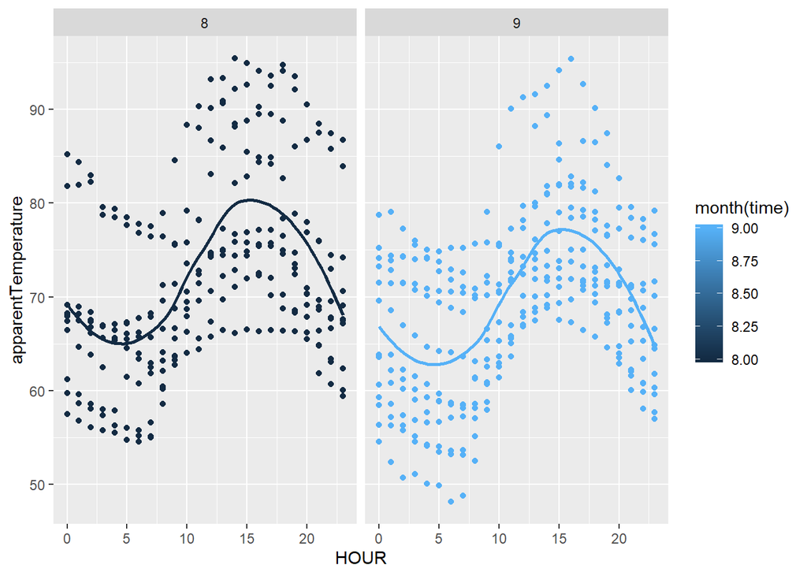

```r
cleanWeather2018 %>% gf_point(apparentTemperature ~ HOUR, color = ~ month(time)) %>% gf_smooth(apparentTemperature~HOUR, method = loess, colorse = TRUE) %>% gf_facet_wrap(~month(time))
```

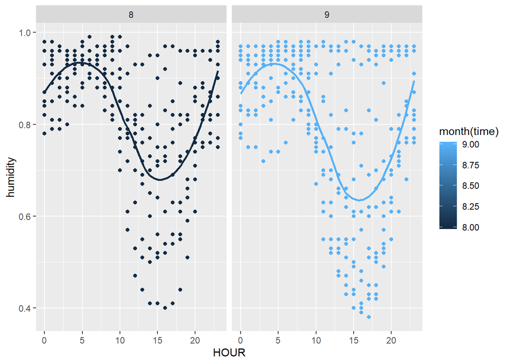

```r
cleanWeather2018 %>% gf_point(humidity ~ HOUR, color = ~ month(time)) %>% gf_smooth(humidity~HOUR, method = loess, colorse = TRUE) %>% gf_facet_wrap(~month(time))
```

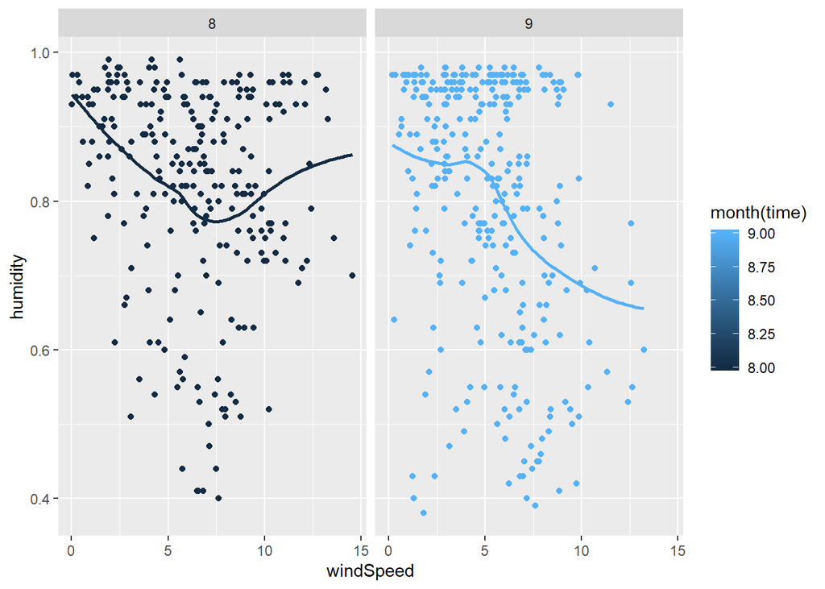

```r
cleanWeather2018 %>% gf_point(humidity ~ windSpeed, color = ~ month(time)) %>% gf_smooth(humidity~windSpeed, method = loess, colorse = TRUE) %>% gf_facet_wrap(~month(time))
```

In 2018 we found that 96% of students that stayed at Loras. This may have been due to majority of the days, humidity was at a level higher than 80%, along with the humidity. The windspeed, when there is a high humidity level, was on average below 10.

```r
cleanWeather2018 %>% group_by(HOUR) %>% summarise(MeanTemp=mean(apparentTemperature))
```

```
## # A tibble: 24 x 2
##     HOUR MeanTemp
##    <int>    <dbl>
##  1     0     67.2
##  2     1     66.6
##  3     2     65.7
##  4     3     64.9
##  5     4     64.3
##  6     5     63.8
##  7     6     63.3
##  8     7     63.3
##  9     8     65.0
## 10     9     67.8
## # ... with 14 more rows
```

## 2019

```r
clean2019 %>%  group_by(flg_NetDep, Dropped) %>%
  count() %>% spread(Dropped, n)
```

```
## # A tibble: 2 x 3
## # Groups:   flg_NetDep [2]
##   flg_NetDep `FALSE` `TRUE`
##        <dbl>   <int>  <int>
## 1          0       1   1227
## 2          1     324      6
```

```r
# 324/330 is who stayed = 0.98181818
```

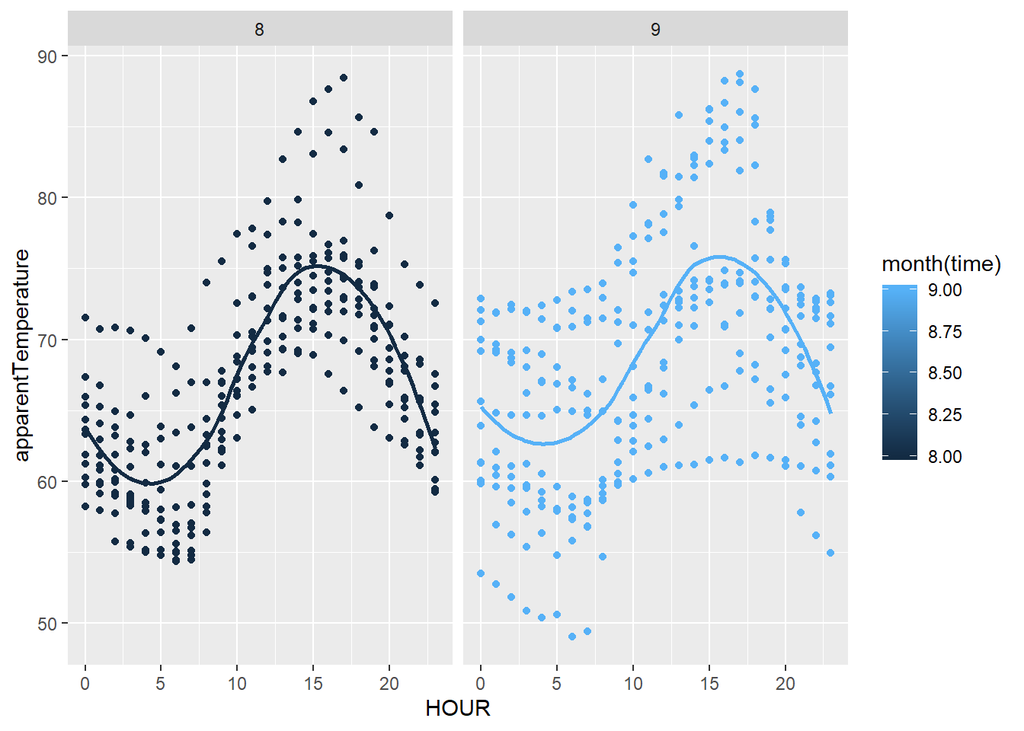

```r
cleanWeather2019 %>% gf_point(apparentTemperature ~ HOUR, color = ~ month(time)) %>% gf_smooth(apparentTemperature~HOUR, method = loess, colorse = TRUE) %>% gf_facet_wrap(~month(time))
```

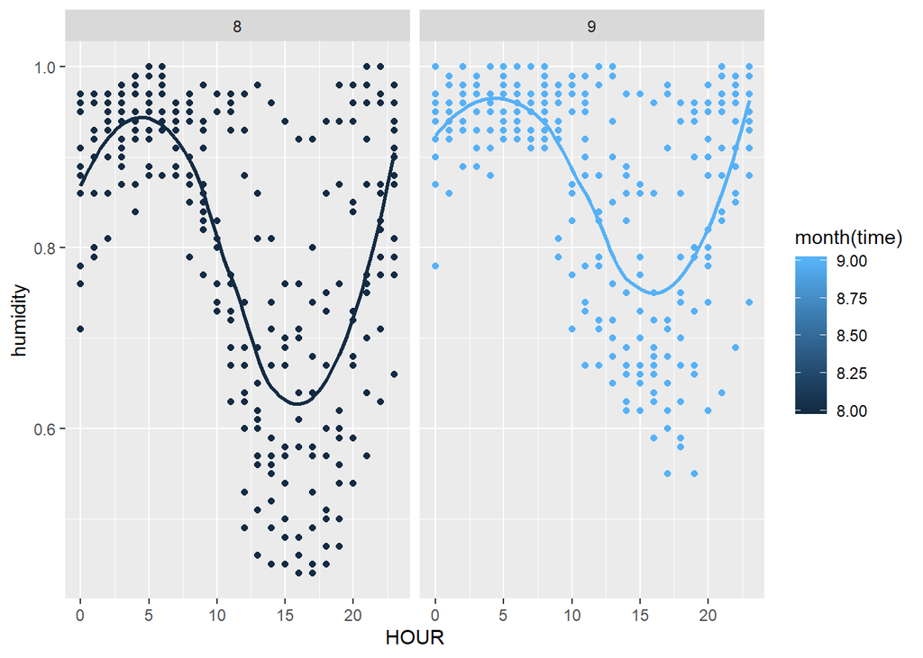

```r
cleanWeather2019 %>% gf_point(humidity ~ HOUR, color = ~ month(time)) %>% gf_smooth(humidity~HOUR, method = loess, colorse = TRUE) %>% gf_facet_wrap(~month(time))
```

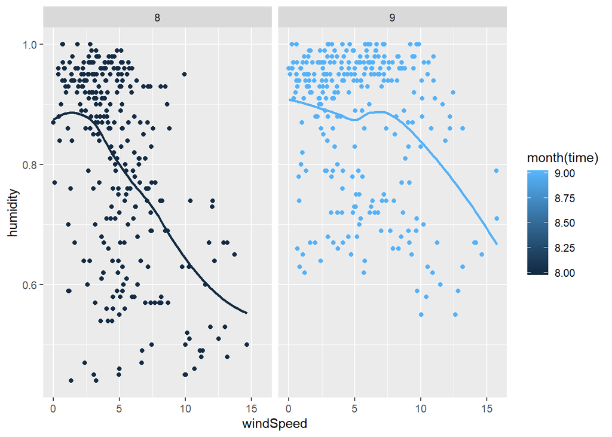

```r
cleanWeather2019 %>% gf_point(humidity ~ windSpeed, color = ~ month(time)) %>% gf_smooth(humidity~windSpeed, method = loess, colorse = TRUE) %>% gf_facet_wrap(~month(time))
```

2019 saw the least amount of people leave within the four year analysis with a total of 6. This could be in part due to the low highs averaging throughout the day for the apparent temperatures in August and September. While the average humidity levels remained high through some days, other saw drops. Along with low wind speeds and high humidity, living conditions could be uncomfortable for some, but as it can be seen, a mojority of the people were able to push through the discomfort and remain at Loras.

```r
cleanWeather2019 %>% group_by(HOUR) %>% summarise(MeanTemp=mean(apparentTemperature))
```

```
## # A tibble: 24 x 2
##     HOUR MeanTemp
##    <int>    <dbl>
##  1     0     64.3
##  2     1     63.3
##  3     2     62.5
##  4     3     61.8
##  5     4     61.4
##  6     5     61.0
##  7     6     60.7
##  8     7     60.9
##  9     8     63.1
## 10     9     65.9
## # ... with 14 more rows
```

Final Thoughts